# PHP 2410E - Assignment 1

# Setup

### PHP 2410E - Class assignment 1

*Project started:* 2019.09.09  
*Documented created* 2019-09-18 15:42:46  
*Programmer:* Kevin W. McConeghy

Assignment as written:

- Data Assignment #1
- Working with Medicare Public Use Files
- Due September 19th, 2019

# Introduction

This is the completed assignment 1 for the ‘Medicare data’ course at Brown University.

All code is stored in a Github repository, https://github.com/kmcconeghy/PHP2410E)

# Statement of work

This document was created solely by the author, guidance in the homework solutions was driven by class instruction, materials or prior experience. The solutions were not shared with anyone else.

## Note on R markdown

This report was generated using R markdown, LaTEX, and several non-base R packages (e.g. tidyverse).

# Assignment Overview

> CMS is committed to increasing access to its Medicare claims data through the release of de-identified data files available for public use. The first phase in this effort is the release of the 5% sample Public Use Files for a variety of Medicare claim types for the periods 2006-2014. These files are available to researchers as free downloads in CSV and/or Excel format, depending upon the year. They contain non-identifiable claim-specific information and are within the public domain.

> Of paramount importance in the release of Public Use Files is the protection of beneficiary confidentiality. To that end all directly identifiable information has been removed. Moreover, other potentially identifying variables, which might cause identification by themselves or enable it in combination with other variables, have either been removed from the files or their values re-coded. See the general documentation file for each claim type for specific information concerning de-identification and variable values.

> The files can be find here: https://www.cms.gov/Research-Statistics-Data-and-Systems/Downloadable-Public-Use-Files/BSAPUFS/index.html

> Each file has its own documentation describing file layout and variable values, as well as program code for creating SAS datasets. Click on the link in the left menu for the specific PUF to access documentation and download instructions.

> Specification of Data Assignment There are five possible PUF files on the CMS web site. Each is described below. Select at least one and do the following:

# Assigment 1.1 Infile the data

> 1. Read the data into a SAS or STATA analysis file using the format statement provided;

## Public Use Files

For this assignment the inpatient file was chosen and downloaded.

https://www.cms.gov/Research-Statistics-Data-and-Systems/Downloadable-Public-Use-Files/BSAPUFS/Downloads/2008_BSA_Inpatient_Claims_PUF.zip

### File downloaded directly

```r
url <- 'https://www.cms.gov/Research-Statistics-Data-and-Systems/Downloadable-Public-Use-Files/BSAPUFS/Downloads/2008_BSA_Inpatient_Claims_PUF.zip'

filename <- '2008_BSA_Inpatient_Claims_PUF.csv'

temp <- tempfile()
download.file(url, temp)
df_raw <- read.csv(unz(temp, filename), header = T)
unlink(temp)
```

### Read in SAS infile statement for labels

CMS provides a SAS infile statement for working with data, this is read in and used to relabel raw .csv file in R.

```r
## https://stackoverflow.com/questions/33421854/how-can-i-import-sas-format-files-into-r
locf <- function(x) {
  x <- data.frame(x, stringsAsFactors = FALSE)
  x[x == ''] <- NA
  indx <- !is.na(x)

  x[] <- lapply(seq_along(x), function(ii) {
    idx <- cumsum(indx[, ii])
    idx[idx == 0] <- NA
    x[, ii][indx[, ii]][idx]
  })
  x[, 1]
}

fmt <- readLines(paste0(wd.data, '\\', 'BSA_Inpatient_Claims_PUF_2008_2.txt'))
## not sure if comments are allowed in the value definitions, but
## this will check for those in case
fmt <- gsub('\\*.*;|\\/\\*.*\\*\\/', '', fmt)

vars <- gsub('(?i)value\\W+(\\w*)|.', '\\1', fmt, perl = TRUE)
vars <- locf(vars)

regex <- '[\'\"].*[\'\"]|[\\w\\d-]+'
vals <- gsub(sprintf('(?i)\\s*(%s)\\s*(=)\\s*(%s)|.', regex, regex),
             '\\1\\2\\3', fmt, perl = TRUE)

dd <- na.omit(data.frame(values = vars, formats = vals,
                              stringsAsFactors = FALSE))

df_lbls <- split(dd$formats, dd$values)
df_lbls <- lapply(df_lbls, function(x) {
  x <- Filter(nzchar, x)
  x <- strsplit(x, '=')
  tw <- function(x) gsub('^\\s+|\\s+$', '', x)
  sapply(x, function(y)
    setNames(tw(y[1]), tw(y[2])))
})

df_lbls <- lapply(df_lbls, function(x) {
  new_names <- str_replace(names(x), pattern='.NA', replacement='')
  names(x) <- new_names
  return(x)
})

# Fix ICDF
sto_names <- names(df_lbls$ICDF)
df_lbls$ICDF <- str_replace_all(df_lbls$ICDF, '[\']', '') %>%
  as.numeric(.)
names(df_lbls$ICDF) <- sto_names
df_lbls$ICDF <- df_lbls$ICDF[-1]
```

### Basic description of file

```r
des_df(df_raw, c('Raw Inpatient PUF for 2008, downloaded from CMS'), 'IP_CLM_ID')
```

```
## Dataframe: Raw Inpatient PUF for 2008, downloaded from CMS
## Memory Size: 67 Mb  Rows: 588,415  Columns: 8
## IP_CLM_ID: 588,415 Missing: 0
```

The file is one row per unique claim ID.

### Comparison to reported statistics from website

#### Extract table results from PDF report

```r
library(tabulizer)
url = 'https://www.cms.gov/Research-Statistics-Data-and-Systems/Downloadable-Public-Use-Files/BSAPUFS/Downloads/2008_Enrollment_and_User_Rates.pdf'

lst_cms_tbls <- extract_tables(url, encoding="UTF-8")
```

#### CMS Reported Inpatient use rates

```r
cms_inpat <- lst_cms_tbls[[3]]

colnames(cms_inpat) <- cms_inpat[1, ]
cms_inpat <- cms_inpat[-1 ,] %>%
  as_tibble(.)

DT::datatable(cms_inpat)
```

|  | V1 | Months of Enrollment | Under 65 | 65 - 69 | 70 - 74 | 75 - 79 | 80 - 84 | 85 and older | Total |
| --- | --- | --- | --- | --- | --- | --- | --- | --- | --- |
| 1 | Female | 12 months | 21.14% | 12.59% | 15.20% | 19.19% | 23.09% | 27.54% | 19.29% |
| 2 | Female | Less than 12 months(2) | 10.81% | 5.85% | 22.11% | 33.39% | 44.18% | 50.49% | 19.42% |
| 3 | Male | 12 months | 17.92% | 12.64% | 15.34% | 18.95% | 22.97% | 26.92% | 17.76% |
| 4 | Male | Less than 12 months(2) | 11.52% | 6.51% | 24.67% | 38.57% | 47.94% | 55.32% | 18.18% |
| 5 | Total |  | 17.93% | 10.86% | 15.80% | 20.26% | 25.01% | 30.77% | 18.64% |

## Data Description

### Confirm infile step

#### Sample table from codebook

```r
url = 'https://www.cms.gov/Research-Statistics-Data-and-Systems/Downloadable-Public-Use-Files/BSAPUFS/Downloads/2008_BSA_Inpatient_Claims_PUF_DataDic_CB.pdf'

lst_dta_tbls <- extract_tables(url, encoding="UTF-8")

cbook_dta_gndr <- lst_dta_tbls[[1]]

colnames(cbook_dta_gndr) <- cbook_dta_gndr[1, ]
cbook_dta_gndr <- cbook_dta_gndr[-1 ,] %>%
  as_tibble(.)

DT::datatable(cbook_dta_gndr)
```

|  | Variable Value | Formatted Value | Frequency | Frequency (%) |
| --- | --- | --- | --- | --- |
| 1 | 1 | Male | 258,217 | 43.883% |
| 2 | 2 | Female | 330,198 | 56.117% |

#### Raw data-file comparison for Sex

```r
df_raw$BENE_SEX_IDENT_CD %>%
  table(.)
```

```
## .
##      1      2
## 258217 330198
```

file loaded into R appears to be consistent with reported tables from CMS.

# Assignment 1.2 Summary statistics

> 2. Run summary statistics on all variables (except the ID number); this is either a frequency distribution for a nominal or ordinal variable and means, standard deviations and percentiles for the continuous variables like expenditures, etc.

## Summary Statistics

First some data-formatting; rename all variables to lower string, factor categories, set the codes to character strings vs. integers.

```r
## Formatting
df_2 <- df_raw %>%
  rename_all(., tolower) %>%
  mutate(ip_clm_id = as.character(ip_clm_id),
         ip_clm_icd9_prcdr_cd = as.character(ip_clm_icd9_prcdr_cd),
         gender = factor(bene_sex_ident_cd,
                         levels = c(1, 2),
                         labels=c('Male', 'Female')),
         age_cat = factor(bene_age_cat_cd,
                          levels = df_lbls$AGEF,
                          labels = names(df_lbls$AGEF)),
         ip_clm_days_cd = factor(ip_clm_days_cd,
                          levels = df_lbls$LOSF,
                          labels = names(df_lbls$LOSF)),
         ip_clm_base_drg_cd = factor(ip_clm_base_drg_cd,
                          levels = df_lbls$DRGF,
                          labels = names(df_lbls$DRGF)),
         ip_clm_icd9_prcdr_cd = factor(ip_clm_icd9_prcdr_cd,
                          levels = df_lbls$ICDF,
                          labels = names(df_lbls$ICDF)),
         ip_drg_quint_pmt_cd = factor(ip_drg_quint_pmt_cd)) %>%
  select(-starts_with('bene'))
```

Structure:

```r
str(select(df_2, -ip_clm_id))
```

```
## 'data.frame':    588415 obs. of  7 variables:
##  $ ip_clm_base_drg_cd  : Factor w/ 311 levels "\"Heart transplant or implant of heart assist system\"",..: 3 199 119 128 236 123 64 284 284 83 ...
##  $ ip_clm_icd9_prcdr_cd: Factor w/ 100 levels "'Not elsewhere classified'",..: 32 NA 55 NA 71 46 NA NA 95 38 ...
##  $ ip_clm_days_cd      : Factor w/ 4 levels "'1 day'","'2-3 days'",..: 4 2 4 2 1 2 2 4 2 3 ...
##  $ ip_drg_quint_pmt_avg: int  86240 3447 34878 3007 3352 2690 5234 2713 9143 23354 ...
##  $ ip_drg_quint_pmt_cd : Factor w/ 5 levels "1","2","3","4",..: 4 2 5 2 2 1 3 2 5 5 ...
##  $ gender              : Factor w/ 2 levels "Male","Female": 2 2 1 2 2 1 1 2 1 2 ...
##  $ age_cat             : Factor w/ 6 levels "'Under  65 '",..: 4 5 1 2 2 1 3 2 1 3 ...
```

### Simple Categorical variables

```r
df_2 %>%
  group_by(gender) %>%
  summarize(n = n(),
            percent = round(n() / nrow(df_2) *100, 2))
```

| gender | n | percent |
| --- | --- | --- |
| Male | 258217 | 43.88 |
| Female | 330198 | 56.12 |

```r
df_2 %>%
  group_by(age_cat) %>%
  summarize(n = n(),
            percent = round(n() / nrow(df_2) *100, 2))
```

| age_cat | n | percent |
| --- | --- | --- |
| 'Under 65 ' | 116080 | 19.73 |
| '65 - 69 ' | 77597 | 13.19 |
| '70 - 74 ' | 86205 | 14.65 |
| '75 - 79 ' | 91487 | 15.55 |
| '80 - 84 ' | 94759 | 16.10 |
| '85 & Older' | 122287 | 20.78 |

```r
df_2 %>%
  group_by(ip_clm_days_cd) %>%
  summarize(n = n(),
            percent = round(n() / nrow(df_2) *100, 2))
```

| ip_clm_days_cd | n | percent |
| --- | --- | --- |
| '1 day' | 76025 | 12.92 |
| '2-3 days' | 261419 | 44.43 |
| '4-7 days' | 122073 | 20.75 |
| '8 or more days' | 128898 | 21.91 |

### Most DRG codes - Top 10 Codes

```r
df_2 %>%
  group_by(ip_clm_base_drg_cd) %>%
  summarize(n = n(),
            percent = round(n() / nrow(df_2) *100, 2)) %>%
  arrange(desc(n)) %>%
  slice(1:10) %>%
  DT::datatable(.)
```

|  | ip_clm_base_drg_cd | n | percent |
| --- | --- | --- | --- |
| 1 | "Heart failure &amp; shock" | 29374 | 4.99 |
| 2 | "Simple pneumonia &amp; pleurisy" | 24317 | 4.13 |
| 3 | "Major joint replacement or reattachment of lower extremity" | 23111 | 3.93 |
| 4 | "Chronic obstructive pulmonary disease" | 22865 | 3.89 |
| 5 | "Psychoses" | 21248 | 3.61 |
| 6 | "Septicemia w/o MV 96+ hours" | 17904 | 3.04 |
| 7 | "Rehabilitation" | 17219 | 2.93 |
| 8 | "Esophagitis, gastroent &amp; misc digest disorders" | 15226 | 2.59 |
| 9 | "Cardiac arrhythmia &amp; conduction disorders" | 14695 | 2.5 |
| 10 | "Kidney &amp; urinary tract infections" | 14127 | 2.4 |

### Most ICD Procedures codes - Top 10 Codes

```r
df_2 %>%
  group_by(ip_clm_icd9_prcdr_cd) %>%
  summarize(n = n(),
            percent = round(n() / nrow(df_2) *100, 2)) %>%
  arrange(desc(n)) %>%
  slice(1:10) %>%
  DT::datatable(.)
```

|  | ip_clm_icd9_prcdr_cd | n | percent |
| --- | --- | --- | --- |
| 1 |  | 276546 | 47 |
| 2 | 'Joint repair' | 33100 | 5.63 |
| 3 | 'Other nonoperative proc' | 29267 | 4.97 |
| 4 | 'Intest incis/excis/anast' | 27553 | 4.68 |
| 5 | 'Other heart/pericard ops' | 21613 | 3.67 |
| 6 | 'Vessel inc/excis/occlus' | 21350 | 3.63 |
| 7 | 'Other ops on vessels' | 19759 | 3.36 |
| 8 | 'Not elsewhere classified' | 18535 | 3.15 |
| 9 | 'Non-op intubat &amp; irrigat' | 13530 | 2.3 |
| 10 | 'Other dx radiology' | 11402 | 1.94 |

### DRG Payment

```r
Hmisc::describe(df_2$ip_drg_quint_pmt_avg)
```

```
## df_2$ip_drg_quint_pmt_avg
##        n  missing distinct     Info     Mean      Gmd      .05      .10
##   588415        0     1458        1     9313     8083     2064     2690
##      .25      .50      .75      .90      .95
##     4008     6352    10760    17800    24558
##
## lowest :      0    253    643    799    842, highest: 174385 211840 222276 226550 329467
```

### Payment distribution

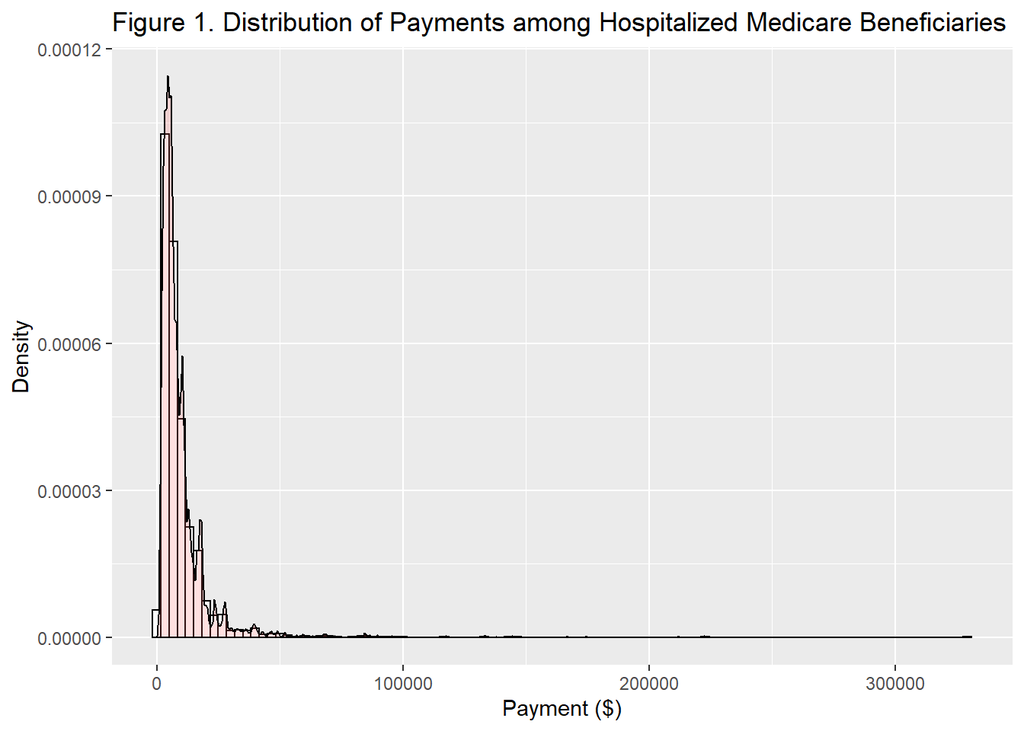

```r
ggplot(df_2, aes(x = ip_drg_quint_pmt_avg)) +
  geom_histogram(bins = 100, aes(y=..density..), colour="black", fill="white") +
  geom_density(alpha=.2, fill="#FF6666") +
  xlab('Payment ($)') + ylab('Density') +
  ggtitle('Figure 1. Distribution of Payments among Hospitalized Medicare Beneficiaries')
```

# Assignment 1.3 Dependent variable:

> 3. Compare some possible dependent variable that characterizes the utilization event (length of stay in days, expenditures, cost or some other analytic variable) by age categories of your choosing and sex.

We will use the `IP_DRG_QUINT_PMT_AVG` variable. Per the data dictionary:  
> Average Medicare total claim payment amount of the quintile for the > payments (of a particular DRG) in the 100% Inpatient claims data for 2008.

Restated this is the average payment for a person of equal sex, age, drg category who is in the same quintile of payment distribution as the person in this limited file. So a reasonable approximation of the payment actually sent to that person.

```r
df_pay <- df_2 %>%
  group_by(gender, age_cat) %>%
  summarize(`Mean ($)` = mean(ip_drg_quint_pmt_avg),
            `SD ($)` = sd(ip_drg_quint_pmt_avg)) %>%
  mutate_at(c(3, 4), list(~prettyNum(., big.mark=',', digits=0))) %>%
  rename(Gender = gender, `Age category` = age_cat)

DT::datatable(df_pay)
```

|  | Gender | Age category | Mean ($) | SD ($) |
| --- | --- | --- | --- | --- |
| 1 | Male | 'Under 65 ' | 9,632 | 11,809 |
| 2 | Male | '65 - 69 ' | 10,650 | 13,035 |
| 3 | Male | '70 - 74 ' | 10,519 | 12,032 |
| 4 | Male | '75 - 79 ' | 10,413 | 11,806 |
| 5 | Male | '80 - 84 ' | 9,745 | 10,830 |
| 6 | Male | '85 &amp; Older' | 8,774 | 8,755 |
| 7 | Female | 'Under 65 ' | 8,750 | 10,333 |
| 8 | Female | '65 - 69 ' | 9,343 | 10,640 |
| 9 | Female | '70 - 74 ' | 9,458 | 10,401 |
| 10 | Female | '75 - 79 ' | 9,285 | 10,154 |

[output cut: 2 more lines]